# User survey for ImagingSociety 2025 - National MRI research infrastructure in Norway

Author

Dr. Athanasia M. Mowinckel

Published

September 17, 2026

## Background

This report presents an analysis of the survey data collected for the national grant scheme application for MRI research infrastructure in Norway. The survey was designed to gather insights from the research community on the current use, needs, and challenges related to MRI for human research.

The following sections will present a summary of the key findings, including graphical representations of the quantitative data and a textual summary of the open-ended responses, with the help of the Gemini LMM.

## Survey Results

Of the 67 responses, 31 participants reported they currently use MRI for research, 46% indicate a future interest in using the new MRI facility for their work.

### Participant Demographics

This section provides an overview of the survey participants’ roles and institutions.

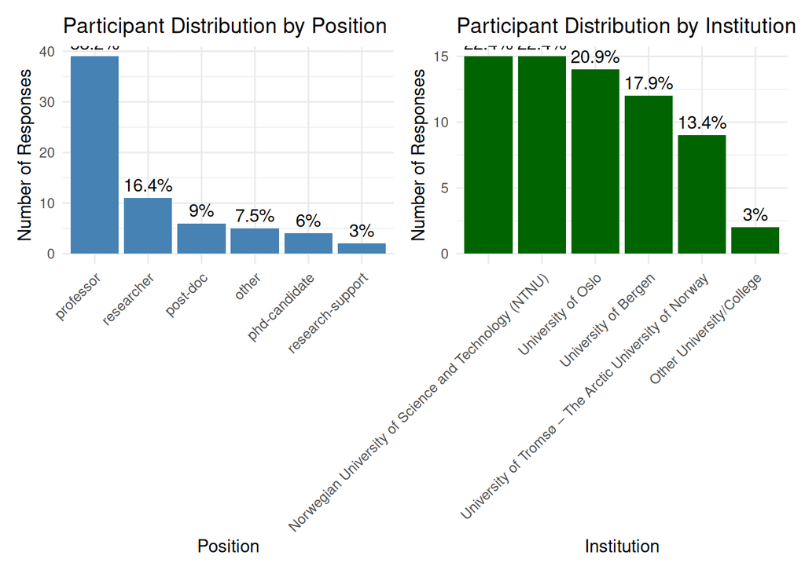

Figure 1: Distribution of Participants by Position and Institution

### Future Needs

This section analyzes which conditions are considered most important for the future of MRI research in Norway.

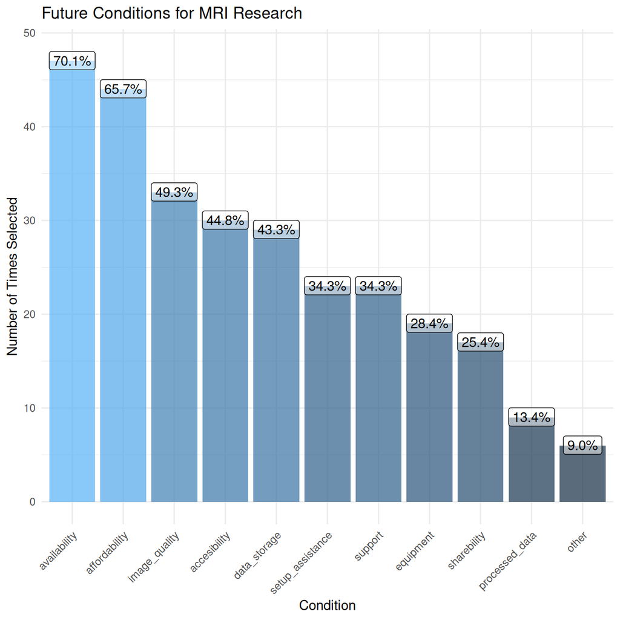

Figure 2: Future Conditions for MRI Research